# An Exercise in Machine Learning

Gary Netherton

November 3, 2015

# Synopsis

Using monitoring devices such as Jawbone Up, Nike FuelBand, and Fitbit allows the user to collect a large amount of data about personal activity. These devices are used to regularly quantify how much of a particular activity done; however, they rarely quantify *how well* the activity was completed. In this project, the goal is to use data from accelerometers on the belt, forearm, arm, and dumbell of 6 participants who were asked to perform barbell lifts correctly and incorrectly in 5 different ways and predict the manner in which they did the exercise using the “classe” variable in the training dataset.

Read in the data:

```
## 'data.frame':    19622 obs. of  160 variables:
##  $ X                       : int  1 2 3 4 5 6 7 8 9 10 ...
##  $ user_name               : Factor w/ 6 levels "adelmo","carlitos",..: 2 2 2 2 2 2 2 2 2 2 ...
##  $ raw_timestamp_part_1    : int  1323084231 1323084231 1323084231 1323084232 1323084232 1323084232 1323084232 1323084232 1323084232 1323084232 ...
##  $ raw_timestamp_part_2    : int  788290 808298 820366 120339 196328 304277 368296 440390 484323 484434 ...
##  $ cvtd_timestamp          : Factor w/ 20 levels "02/12/2011 13:32",..: 9 9 9 9 9 9 9 9 9 9 ...
##  $ new_window              : Factor w/ 2 levels "no","yes": 1 1 1 1 1 1 1 1 1 1 ...
##  $ num_window              : int  11 11 11 12 12 12 12 12 12 12 ...
##  $ roll_belt               : num  1.41 1.41 1.42 1.48 1.48 1.45 1.42 1.42 1.43 1.45 ...
##  $ pitch_belt              : num  8.07 8.07 8.07 8.05 8.07 8.06 8.09 8.13 8.16 8.17 ...
##  $ yaw_belt                : num  -94.4 -94.4 -94.4 -94.4 -94.4 -94.4 -94.4 -94.4 -94.4 -94.4 ...
##  $ total_accel_belt        : int  3 3 3 3 3 3 3 3 3 3 ...
##  $ kurtosis_roll_belt      : Factor w/ 397 levels "","-0.016850",..: 1 1 1 1 1 1 1 1 1 1 ...
##  $ kurtosis_picth_belt     : Factor w/ 317 levels "","-0.021887",..: 1 1 1 1 1 1 1 1 1 1 ...
##  $ kurtosis_yaw_belt       : Factor w/ 2 levels "","#DIV/0!": 1 1 1 1 1 1 1 1 1 1 ...
```

[output cut: 86 more lines]

# Building Models

When building a model, the goal is to accurately predict the “classe” output in the data set. Class “A” corresponds to executing the exercise properly while the other classes, “B” through “E”, correspond to common mistakes. We’ll first look at the “classe” data to see what we’re confronting. We’ll also go ahead and split the training data into a 90/10 grouping so that we can use 10% of the training set for cross-validation.

```
##    A    B    C    D    E
## 5580 3797 3422 3216 3607
```

```
##  Factor w/ 5 levels "A","B","C","D",..: 1 1 1 1 1 1 1 1 1 1 ...
```

Next we’ll use the gbm package to run our data and create our model. I did try running another modelling tecnique, but it took quite a long time on my work laptop (Intel i7 processor with 16 GB of RAM, though I doubt R accessed anything in that neighborhood).

```r
set.seed(12358)
system.time(modFit <- train(classe ~ user_name + pitch_arm + yaw_arm + roll_arm + roll_belt + pitch_belt + yaw_belt +
                                gyros_belt_x + gyros_belt_y + gyros_belt_z + accel_belt_x + accel_belt_y + accel_belt_z +
                                magnet_belt_x + magnet_belt_y + magnet_belt_z + gyros_arm_x + gyros_arm_y + gyros_arm_z +
                                accel_arm_x + accel_arm_y + accel_arm_z + magnet_arm_x + magnet_arm_y + magnet_arm_z +
                                roll_dumbbell + pitch_dumbbell + yaw_dumbbell, method="gbm", data=trainingSub, verbose=FALSE))
```

```
##    user  system elapsed
## 1284.57    1.93 1286.59
```

```r
print(modFit)
```

```
## Stochastic Gradient Boosting
##
## 17662 samples
##   159 predictor
##     5 classes: 'A', 'B', 'C', 'D', 'E'
##
## No pre-processing
## Resampling: Bootstrapped (25 reps)
## Summary of sample sizes: 17662, 17662, 17662, 17662, 17662, 17662, ...
## Resampling results across tuning parameters:
##
##   interaction.depth  n.trees  Accuracy   Kappa      Accuracy SD
##   1                   50      0.6546278  0.5600261  0.005127637
##   1                  100      0.7067132  0.6278382  0.004846309
##   1                  150      0.7425084  0.6738890  0.005500581
##   2                   50      0.7645021  0.7018199  0.006308789
##   2                  100      0.8341649  0.7901877  0.006272755
##   2                  150      0.8692741  0.8346249  0.005269314
##   3                   50      0.8295259  0.7843026  0.005955900
##   3                  100      0.8876531  0.8578759  0.004941692
##   3                  150      0.9146724  0.8921028  0.004202150
##   Kappa SD
##   0.006357165
##   0.006136397
##   0.007011768
##   0.007849619
##   0.007908474
##   0.006658585
##   0.007507418
##   0.006262103
##   0.005338907
##
## Tuning parameter 'shrinkage' was held constant at a value of 0.1
##
## Tuning parameter 'n.minobsinnode' was held constant at a value of 10
## Accuracy was used to select the optimal model using  the largest value.
## The final values used for the model were n.trees = 150,
##  interaction.depth = 3, shrinkage = 0.1 and n.minobsinnode = 10.
```

```r
predictTr <- predict(modFit,trainingSub)
table(predictTr, trainingSub$classe)
```

```
##
## predictTr    A    B    C    D    E
##         A 4721  135   42   54   39
##         B   92 3138  109   18   39
##         C   71  114 2861  129   21
##         D   97   13   57 2675   12
##         E   41   18   11   19 3136
```

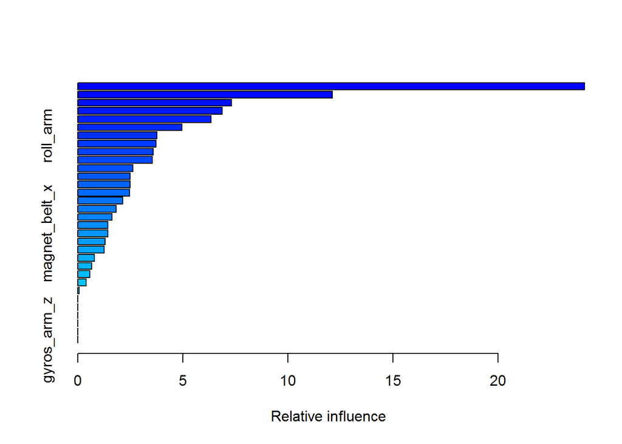

```
##                                 var     rel.inf
## roll_belt                 roll_belt 24.12577975
## yaw_belt                   yaw_belt 12.12550090
## magnet_belt_z         magnet_belt_z  7.31423265
## pitch_belt               pitch_belt  6.88708283
## roll_dumbbell         roll_dumbbell  6.35517620
## magnet_arm_x           magnet_arm_x  4.96475375
## roll_arm                   roll_arm  3.76860787
## magnet_arm_z           magnet_arm_z  3.72142199
## accel_arm_x             accel_arm_x  3.59659143
## gyros_belt_z           gyros_belt_z  3.55163773
## yaw_dumbbell           yaw_dumbbell  2.61708437
## user_nameeurico     user_nameeurico  2.48626278
## yaw_arm                     yaw_arm  2.48545481
## pitch_dumbbell       pitch_dumbbell  2.47405970
## pitch_arm                 pitch_arm  2.14283434
## accel_arm_z             accel_arm_z  1.82384064
## accel_belt_z           accel_belt_z  1.63933043
## gyros_arm_y             gyros_arm_y  1.44179158
## magnet_belt_x         magnet_belt_x  1.42570441
## magnet_belt_y         magnet_belt_y  1.30210185
## magnet_arm_y           magnet_arm_y  1.25630069
## user_namecharles   user_namecharles  0.78890446
## gyros_belt_y           gyros_belt_y  0.67127576
## accel_arm_y             accel_arm_y  0.57154839
## gyros_arm_x             gyros_arm_x  0.39903884
## gyros_belt_x           gyros_belt_x  0.06368184
## user_namecarlitos user_namecarlitos  0.00000000
## user_namejeremy     user_namejeremy  0.00000000
## user_namepedro       user_namepedro  0.00000000
## accel_belt_x           accel_belt_x  0.00000000
## accel_belt_y           accel_belt_y  0.00000000
## gyros_arm_z             gyros_arm_z  0.00000000
```

```r
summary(modFit,n.trees=150)
```

The model correctly classifies over 93% of the observations in the training sub-sample using 150 trees. The *roll_belt* and *yaw_belt* features appear to be the most influential.

We can look at a plot of these top two features colored by outcome.

They are not the best predictors on their own, but the plot shows groupings. This confirms that a boosting algorithm was a good choice since there is a large set of relatively weak predictors. This second plot further demonstrates the improved performance gained by using boosting iterations.

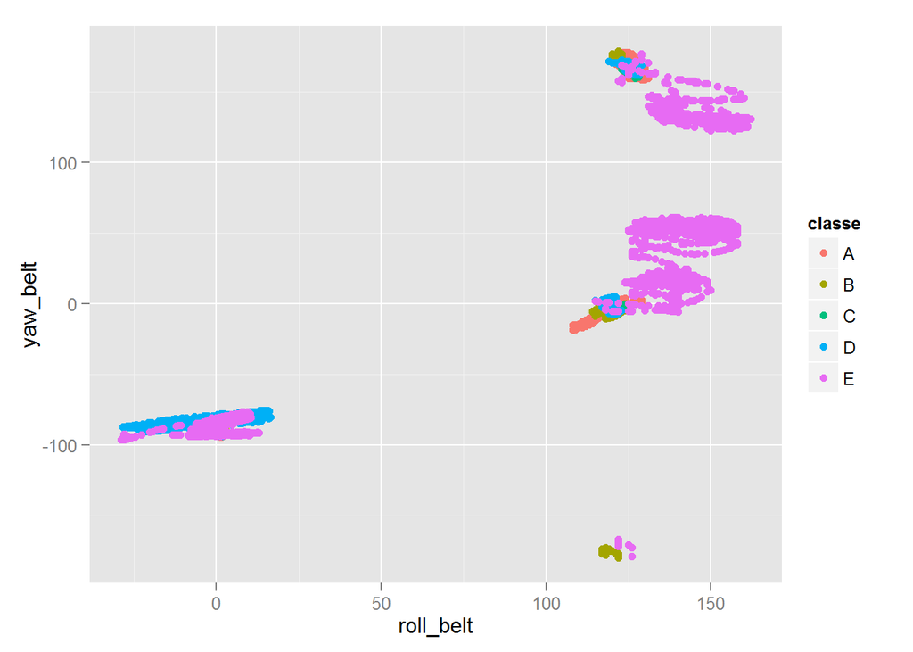

```r
qplot(roll_belt, yaw_belt,colour=classe,data=trainingSub)
```

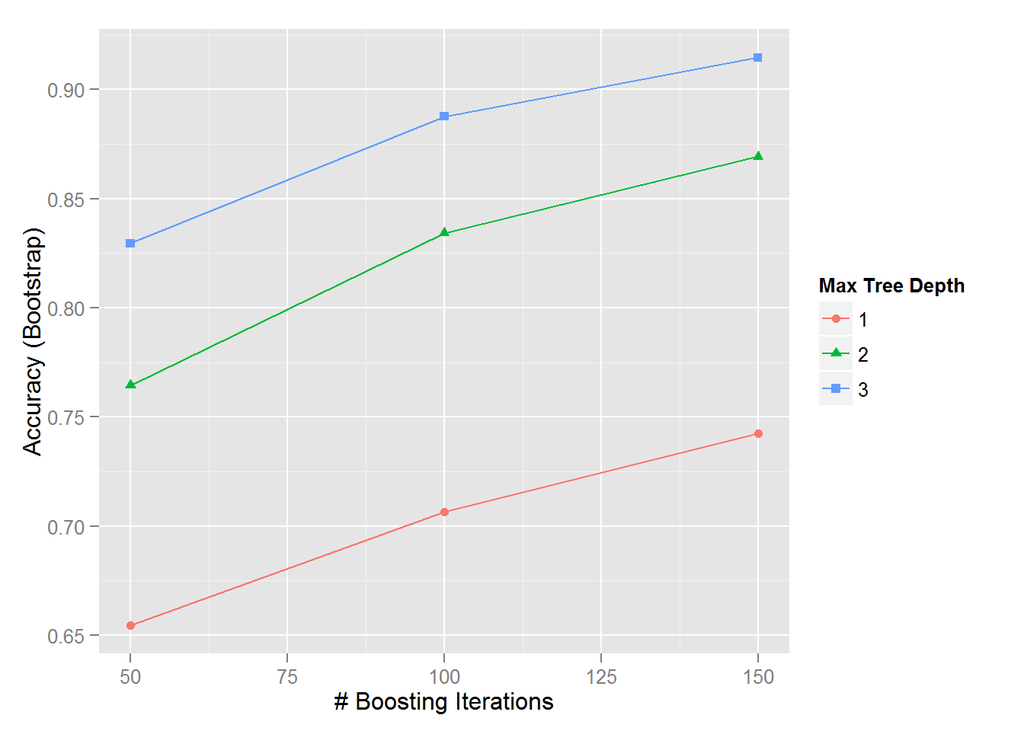

```r
ggplot(modFit)
```

Now, I have to check the performance on the 10 percent subsample to get an estimate of the algorithm’s out-of-sample performance.

```r
predictTe <- predict(modFit,testingSub)
table(predictTe, testingSub$classe)
```

```
##
## predictTe   A   B   C   D   E
##         A 529  21   5  10   4
##         B   7 339  15   4   6
##         C   4  16 315  14   3
##         D  14   2   5 288   1
##         E   4   1   2   5 346
```

The following code is for submission for grading - taken from the Coursera website as offered by Dr. Leek.

```r
answers <- as.character(predict(modFit, testing))
pml_write_files = function(x){
  n = length(x)
  for(i in 1:n){
    filename = paste0("problem_id_",i,".txt")
    write.table(x[i],file=filename,quote=FALSE,row.names=FALSE,col.names=FALSE)
  }
}
pml_write_files(answers)
```

# References

[see Ugulino, W.; Cardador, D.; Vega, K.; Velloso, E.; Milidiu, R.; Fuks, H. Wearable Computing: Accelerometers’ Data Classification of Body Postures and Movements. Proceedings of 21st Brazilian Symposium on Artificial Intelligence. Advances in Artificial Intelligence - SBIA 2012. In: Lecture Notes in Computer Science. , pp. 52-61. Curitiba, PR: Springer Berlin / Heidelberg, 2012. ISBN 978-3-642-34458-9. DOI: 10.1007/978-3-642-34459-6_6].